# Close spouse

# 1 Description of DataSchema variable

The description of harmonised variable is the following:

- Short name: `close_spouse`
- Variable label: `Is the relationship with the spouse close?`
- Variable description: `Is the relationship with the spouse close?`
- Domain: `Social environment`
- Value type: `categorical`
- Category coding:

| **Code** | **Category Label** |
| --- | --- |
| 0 | No |
| 1 | Yes |

- Category missings:

| **Code** | **Category Label** |
| --- | --- |
| 991 | CAPI/interviewer error |
| 992 | Impute |
| 993 | Disable to measure |
| 994 | Not attempt/not done |
| 995 | Does not answer |
| 996 | Not applicable |
| 997 | Refuse |
| 998 | Do not know |
| 999 | Missing |

# 2 Data process

## 2.1 England

### 2.1.1 Wave 1

#### 2.1.1.1 Study-specific variable description

The study-specific variable elected to be harmonised is:

- Name: `scptrg`
- Label: `how close is your relationship with your spouse or partner?`
- Categories:
  - `1 = Very close`
  - `2 = Quite close`
  - `3 = Not very close`
  - `4 = Not at all close`
- Missings:
  - `-9 = Not answered (9)`
  - `-1 = Item not applicable`

```
## $values_table
##               -9      -1       1       2   3     4
## Frequency  80.00 4166.00 5975.00 1594.00 242 42.00
## Percentage  0.66   34.43   49.38   13.17   2  0.35
##
## $n_table
##      Sample size Missing values
## [1,]       12099              0
```

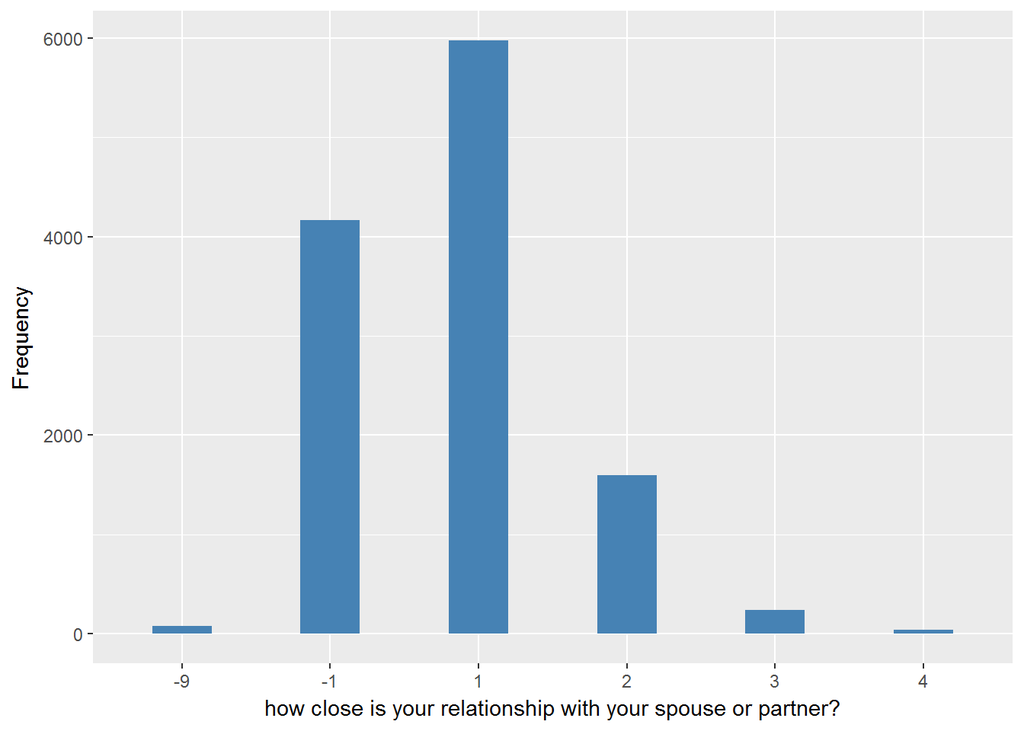

#### 2.1.1.2 Harmonisation algorithm

To compute the harmonize variable from the study-specific variable it has to be recoded as follows:

- `3 or 4 into 0`
- `1 or 2 into 1`
- `-9 into 995`
- `-1 into 996`
- `NA into 999`

**R script:**

```r
ELSA_ds_w1 <- tibble(id = ELSA_w1_close_spouse$id)
ELSA_ds_w1$close_spouse <- car::recode(as.vector(ELSA_w1_close_spouse$scptrg),
    "1:2='1'; 3:4='0'; -1='996'; -9='995'; NA='999'")
ELSA_ds_w1$close_spouse <- labelled(ELSA_ds_w1$close_spouse, labels = c(No = 0,
    Yes = 1, Missing = 999, `Do not know` = 998, Refuse = 997, `Not applicable` = 996,
    `Don't answer` = 995, `Not attempt/not done/not yet recorded` = 994, `Disable to measure` = 993,
    Impute = 992, `CAPI/interviewer error` = 991))
```

#### 2.1.1.3 Statistics of the new harmonised variable

```
## $values_table
##                 0       1
## Frequency  284.00 7569.00
## Percentage   2.35   62.56
##
## $missing_values_table
##            991 992 993 994   995     996 997 998 999 NA
## Frequency    0   0   0   0 80.00 4166.00   0   0   0  0
## Percentage   0   0   0   0  0.66   34.43   0   0   0  0
##
## $n_table
##      Sample size Missing values
## [1,]       12099           4246
```

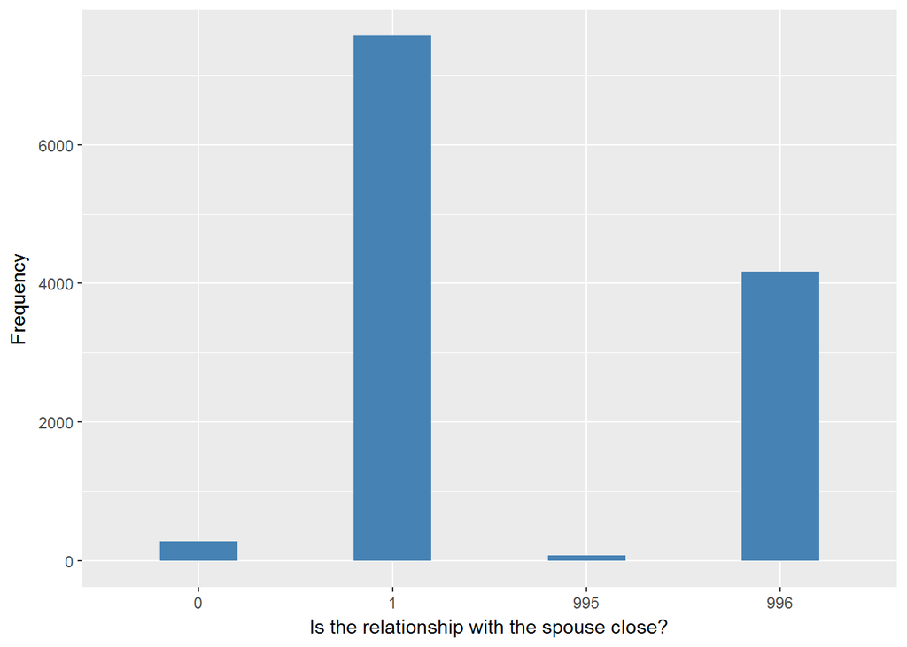

#### 2.1.1.4 Validation

|  | 3:4->0 | 1:2->1 | -9->995 | -1->996 |
| --- | --- | --- | --- | --- |
| BeforeH1 | 284 | 7569 | 80 | 4166 |
| AfterH | 284 | 7569 | 80 | 4166 |

### 2.1.2 Wave 2

#### 2.1.2.1 Study-specific variable description

The study-specific variable elected to be harmonised is:

- Name: `scptrg`
- Label: `How close the respondents relationship to their spouse/partner is`
- Categories:
  - `1 = Very close`
  - `2 = Quite close`
  - `3 = Not very close`
  - `4 = Not at all close`
- Missings:
  - `-9 = Not answered`
  - `-1 = Item not applicable`

```
## $values_table
##               -9      -1       1      2      3     4
## Frequency  51.00 3468.00 4451.00 1264.0 166.00 32.00
## Percentage  0.54   36.77   47.19   13.4   1.76  0.34
##
## $n_table
##      Sample size Missing values
## [1,]        9432              0
```

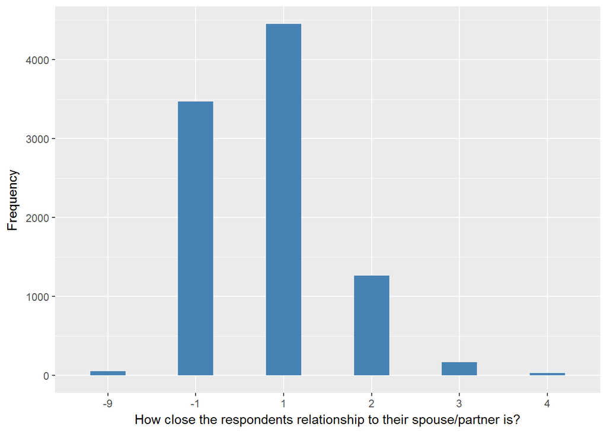

#### 2.1.2.2 Harmonisation algorithm

To compute the harmonize variable from the study-specific variable it has to be recoded as follows:

- `3 or 4 into 0`
- `1 or 2 into 1`
- `-9 into 995`
- `-1 into 996`
- `NA into 999`

**R script:**

```r
ELSA_ds_w2 <- tibble(id = ELSA_w2_close_spouse$id)
ELSA_ds_w2$close_spouse <- car::recode(as.vector(ELSA_w2_close_spouse$scptrg),
    "1:2='1'; 3:4='0'; -1='996'; -9='995'; NA='999'")
ELSA_ds_w2$close_spouse <- labelled(ELSA_ds_w2$close_spouse, labels = c(No = 0,
    Yes = 1, Missing = 999, `Do not know` = 998, Refuse = 997, `Not applicable` = 996,
    `Don't answer` = 995, `Not attempt/not done/not yet recorded` = 994, `Disable to measure` = 993,
    Impute = 992, `CAPI/interviewer error` = 991))
```

#### 2.1.2.3 Statistics of the new harmonised variable

```
## $values_table
##                0       1
## Frequency  198.0 5715.00
## Percentage   2.1   60.59
##
## $missing_values_table
##            991 992 993 994   995     996 997 998 999 NA
## Frequency    0   0   0   0 51.00 3468.00   0   0   0  0
## Percentage   0   0   0   0  0.54   36.77   0   0   0  0
##
## $n_table
##      Sample size Missing values
## [1,]        9432           3519
```

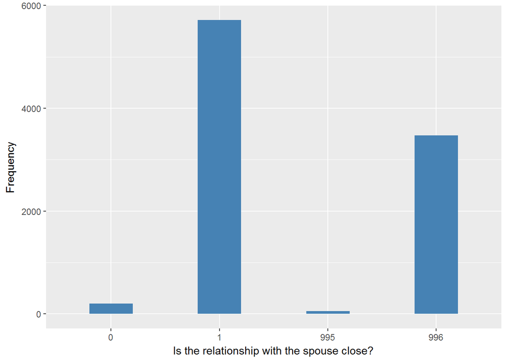

#### 2.1.2.4 Validation

|  | 3:4->0 | 1:2->1 | -9->995 | -1->996 |
| --- | --- | --- | --- | --- |
| BeforeH1 | 198 | 5715 | 51 | 3468 |
| AfterH | 198 | 5715 | 51 | 3468 |

### 2.1.3 Wave 3

#### 2.1.3.1 Study-specific variable description

The study-specific variable elected to be harmonised is:

- Name: `scptrg`
- Label: `How close the respondents relationship to their spouse/partner is`
- Categories:
  - `1 = Very close`
  - `2 = Quite close`
  - `3 = Not very close`
  - `4 = Not at all close`
- Missings:
  - `-9 = Not answered`
  - `-8 = Don't know`
  - `-1 = Item not applicable`

```
## $values_table
##               -9      -1       1       2      3     4
## Frequency  73.00 3789.00 4487.00 1194.00 202.00 26.00
## Percentage  0.75   38.78   45.92   12.22   2.07  0.27
##
## $n_table
##      Sample size Missing values
## [1,]        9771              0
```

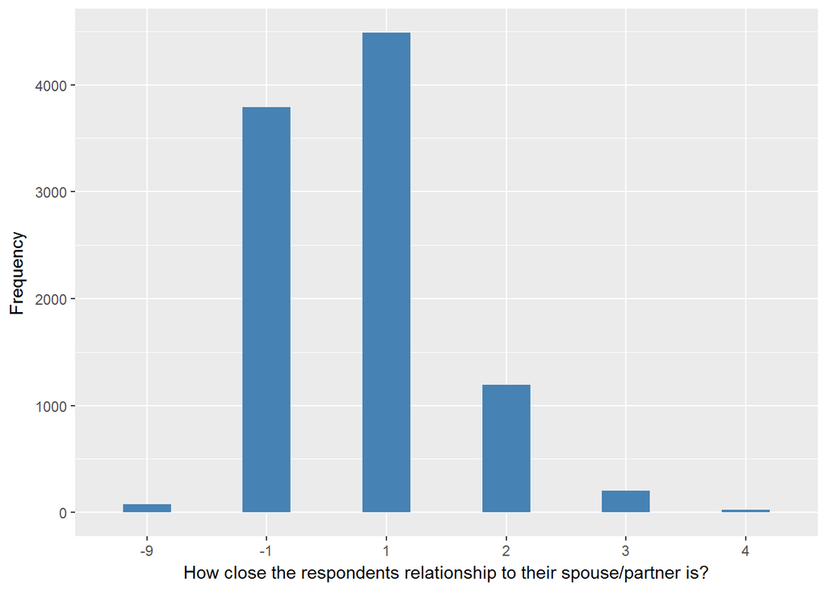

#### 2.1.3.2 Harmonisation algorithm

To compute the harmonize variable from the study-specific variable it has to be recoded as follows:

- `3 or 4 into 0`
- `1 or 2 into 1`
- `-9 into 995`
- `-8 into 998`
- `-1 into 996`
- `NA into 999`

**R script:**

```r
ELSA_ds_w3 <- tibble(id = ELSA_w3_close_spouse$id)
ELSA_ds_w3$close_spouse <- car::recode(as.vector(ELSA_w3_close_spouse$scptrg),
    "1:2='1'; 3:4='0'; -1='996'; -8='998'; -9='995'; NA='999'")
ELSA_ds_w3$close_spouse <- labelled(ELSA_ds_w3$close_spouse, labels = c(No = 0,
    Yes = 1, Missing = 999, `Do not know` = 998, Refuse = 997, `Not applicable` = 996,
    `Don't answer` = 995, `Not attempt/not done/not yet recorded` = 994, `Disable to measure` = 993,
    Impute = 992, `CAPI/interviewer error` = 991))
```

#### 2.1.3.3 Statistics of the new harmonised variable

```
## $values_table
##                 0       1
## Frequency  228.00 5681.00
## Percentage   2.33   58.14
##
## $missing_values_table
##            991 992 993 994   995     996 997 998 999 NA
## Frequency    0   0   0   0 73.00 3789.00   0   0   0  0
## Percentage   0   0   0   0  0.75   38.78   0   0   0  0
##
## $n_table
##      Sample size Missing values
## [1,]        9771           3862
```

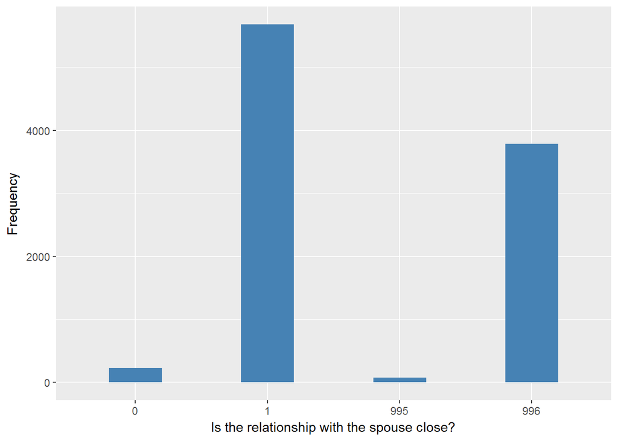

#### 2.1.3.4 Validation

|  | 3:4->0 | 1:2->1 | -9->995 | -1->996 |
| --- | --- | --- | --- | --- |
| BeforeH1 | 228 | 5681 | 73 | 3789 |
| AfterH | 228 | 5681 | 73 | 3789 |

### 2.1.4 Wave 4

#### 2.1.4.1 Study-specific variable description

The study-specific variable elected to be harmonised is:

- Name: `scptrg`
- Label: `How close the respondents relationship to their spouse/partner is`
- Categories:
  - `1 = Very close`
  - `2 = Quite close`
  - `3 = Not very close`
  - `4 = Not at all close`
- Missings:
  - `-9 = Not answered`
  - `-8 = Don't know (8)`
  - `-1 = Item not applicable`

```
## $values_table
##               -9      -1       1       2      3     4
## Frequency  49.00 4220.00 5108.00 1416.00 225.00 32.00
## Percentage  0.44   38.19   46.23   12.81   2.04  0.29
##
## $n_table
##      Sample size Missing values
## [1,]       11050              0
```

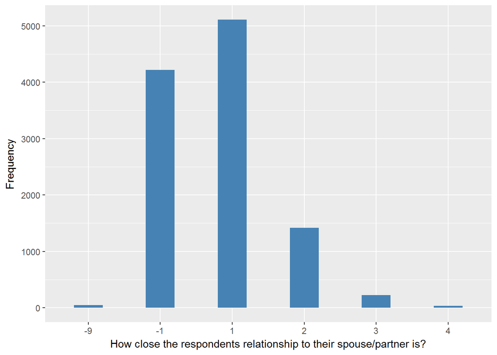

#### 2.1.4.2 Harmonisation algorithm

To compute the harmonize variable from the study-specific variable it has to be recoded as follows:

- `3 or 4 into 0`
- `1 or 2 into 1`
- `-9 into 995`
- `-8 into 998`
- `-1 into 996`
- `NA into 999`

**R script:**

```r
ELSA_ds_w4 <- tibble(id = ELSA_w4_close_spouse$id)
ELSA_ds_w4$close_spouse <- car::recode(as.vector(ELSA_w4_close_spouse$scptrg),
    "1:2='1'; 3:4='0'; -1='996'; -8='998'; -9='995'; NA='999'")
ELSA_ds_w4$close_spouse <- labelled(ELSA_ds_w4$close_spouse, labels = c(No = 0,
    Yes = 1, Missing = 999, `Do not know` = 998, Refuse = 997, `Not applicable` = 996,
    `Don't answer` = 995, `Not attempt/not done/not yet recorded` = 994, `Disable to measure` = 993,
    Impute = 992, `CAPI/interviewer error` = 991))
```

#### 2.1.4.3 Statistics of the new harmonised variable

```
## $values_table
##                 0       1
## Frequency  257.00 6524.00
## Percentage   2.33   59.04
##
## $missing_values_table
##            991 992 993 994   995     996 997 998 999 NA
## Frequency    0   0   0   0 49.00 4220.00   0   0   0  0
## Percentage   0   0   0   0  0.44   38.19   0   0   0  0
##
## $n_table
##      Sample size Missing values
## [1,]       11050           4269
```

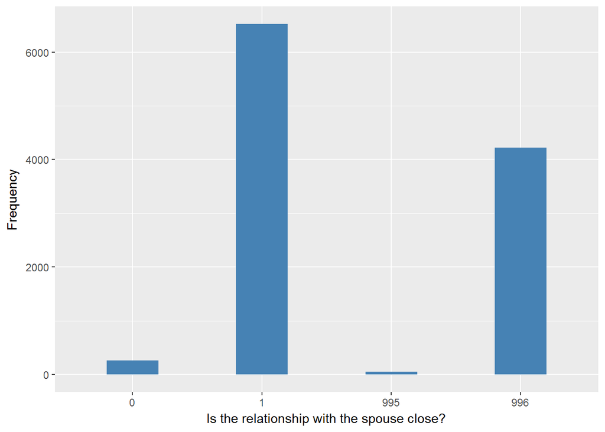

#### 2.1.4.4 Validation

|  | 3:4->0 | 1:2->1 | -9->995 | -1->996 |
| --- | --- | --- | --- | --- |
| BeforeH1 | 257 | 6524 | 49 | 4220 |
| AfterH | 257 | 6524 | 49 | 4220 |

### 2.1.5 Wave 5

#### 2.1.5.1 Study-specific variable description

The study-specific variable elected to be harmonised is:

- Name: `scptrg`
- Label: `How close the respondents relationship to their spouse/partner is`
- Categories:
  - `1 = Very close`
  - `2 = Quite close`
  - `3 = Not very close`
  - `4 = Not at all close`
- Missings:
  - `-9 = Not answered`
  - `-8 = Don't know (8)`
  - `-2 = Schedule Not Applicable`
  - `-1 = Item not applicable`

```
## $values_table
##               -9      -2      -1       1       2      3     4
## Frequency  54.00 1244.00 2552.00 4903.00 1270.00 217.00 34.00
## Percentage  0.53   12.11   24.84   47.72   12.36   2.11  0.33
##
## $n_table
##      Sample size Missing values
## [1,]       10274              0
```

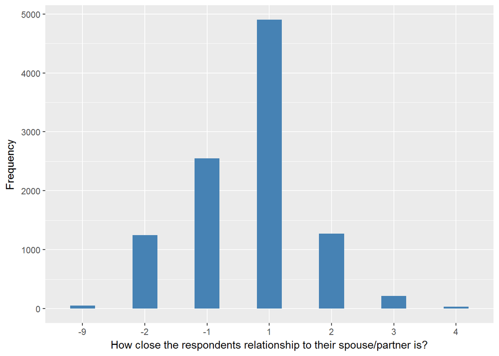

#### 2.1.5.2 Harmonisation algorithm

To compute the harmonize variable from the study-specific variable it has to be recoded as follows:

- `3 or 4 into 0`
- `1 or 2 into 1`
- `-9 into 995`
- `-8 into 998`
- `-2 into 996`
- `-1 into 996`
- `NA into 999`

**R script:**

```r
ELSA_ds_w5 <- tibble(id = ELSA_w5_close_spouse$id)
ELSA_ds_w5$close_spouse <- car::recode(as.vector(ELSA_w5_close_spouse$scptrg),
    "1:2='1'; 3:4='0'; -1='996'; -2='996'; -8='998'; -9='995'; NA='999'")
ELSA_ds_w5$close_spouse <- labelled(ELSA_ds_w5$close_spouse, labels = c(No = 0,
    Yes = 1, Missing = 999, `Do not know` = 998, Refuse = 997, `Not applicable` = 996,
    `Don't answer` = 995, `Not attempt/not done/not yet recorded` = 994, `Disable to measure` = 993,
    Impute = 992, `CAPI/interviewer error` = 991))
```

#### 2.1.5.3 Statistics of the new harmonised variable

```
## $values_table
##                 0       1
## Frequency  251.00 6173.00
## Percentage   2.44   60.08
##
## $missing_values_table
##            991 992 993 994   995     996 997 998 999 NA
## Frequency    0   0   0   0 54.00 3796.00   0   0   0  0
## Percentage   0   0   0   0  0.53   36.95   0   0   0  0
##
## $n_table
##      Sample size Missing values
## [1,]       10274           3850
```

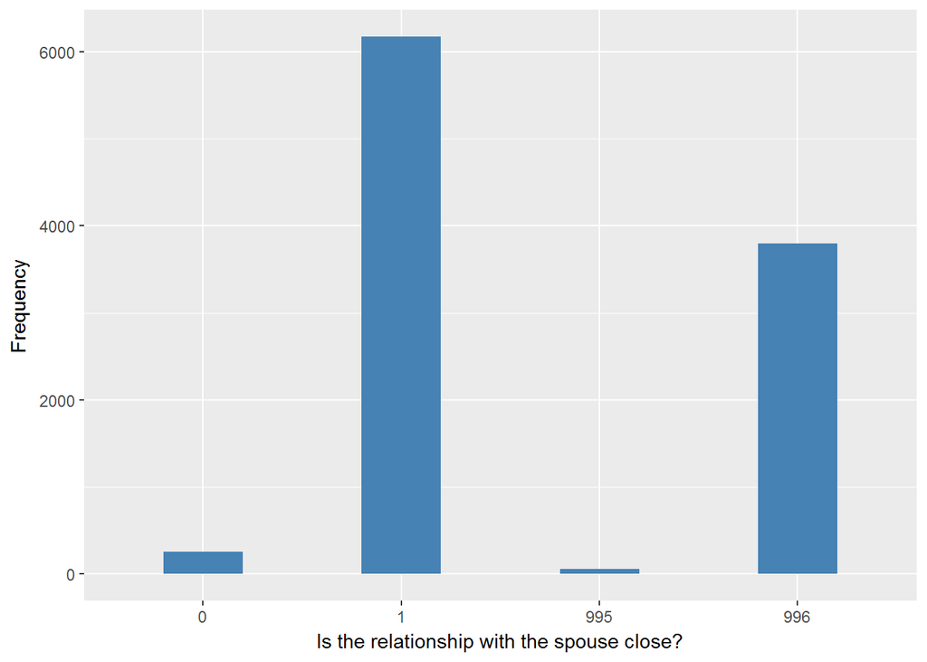

#### 2.1.5.4 Validation

|  | 3:4->0 | 1:2->1 | -9->995 | -1&-2->996 |
| --- | --- | --- | --- | --- |
| BeforeH1 | 251 | 6173 | 54 | 3796 |
| AfterH | 251 | 6173 | 54 | 3796 |

### 2.1.6 Wave 6

#### 2.1.6.1 Study-specific variable description

The study-specific variable elected to be harmonised is:

- Name: `scptrg`
- Label: `How close the respondents relationship to their spouse/partner is`
- Categories:
  - `1 = Very close`
  - `2 = Quite close`
  - `3 = Not very close`
  - `4 = Not at all close`
- Missings:
  - `-9 = Not answered (9)`
  - `-8 = Don't know (8)`
  - `-2 = Schedule Not Applicable`
  - `-1 = Item not applicable`

```
## $values_table
##               -9      -2      -1       1       2      3     4
## Frequency  46.00 1604.00 2432.00 4953.00 1273.00 255.00 38.00
## Percentage  0.43   15.13   22.94   46.72   12.01   2.41  0.36
##
## $n_table
##      Sample size Missing values
## [1,]       10601              0
```

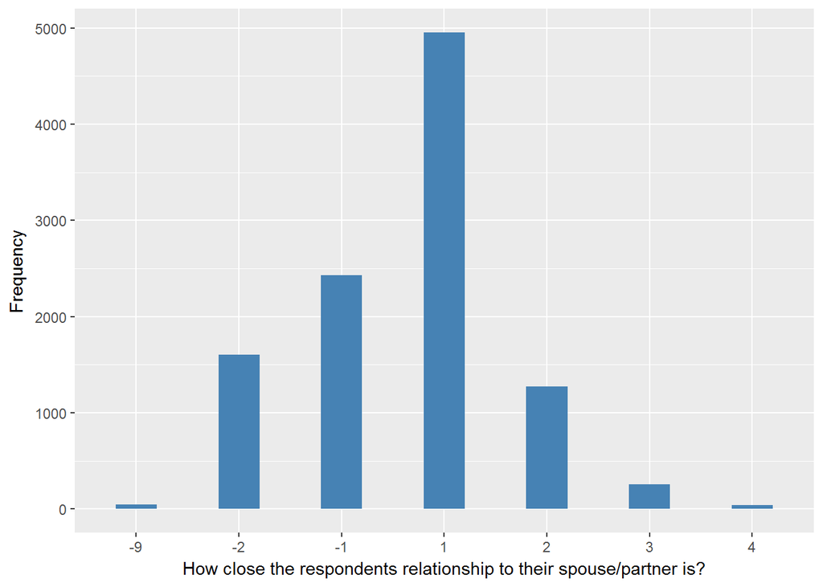

#### 2.1.6.2 Harmonisation algorithm

To compute the harmonize variable from the study-specific variable it has to be recoded as follows:

- `3 or 4 into 0`
- `1 or 2 into 1`
- `-9 into 995`
- `-8 into 998`
- `-2 into 996`
- `-1 into 996`
- `NA into 999`

**R script:**

```r
ELSA_ds_w6 <- tibble(id = ELSA_w6_close_spouse$id)
ELSA_ds_w6$close_spouse <- car::recode(as.vector(ELSA_w6_close_spouse$scptrg),
    "1:2='1'; 3:4='0'; -1='996'; -2='996'; -8='998'; -9='995'; NA='999'")
ELSA_ds_w6$close_spouse <- labelled(ELSA_ds_w6$close_spouse, labels = c(No = 0,
    Yes = 1, Missing = 999, `Do not know` = 998, Refuse = 997, `Not applicable` = 996,
    `Don't answer` = 995, `Not attempt/not done/not yet recorded` = 994, `Disable to measure` = 993,
    Impute = 992, `CAPI/interviewer error` = 991))
```

#### 2.1.6.3 Statistics of the new harmonised variable

```
## $values_table
##                 0       1
## Frequency  293.00 6226.00
## Percentage   2.76   58.73
##
## $missing_values_table
##            991 992 993 994   995     996 997 998 999 NA
## Frequency    0   0   0   0 46.00 4036.00   0   0   0  0
## Percentage   0   0   0   0  0.43   38.07   0   0   0  0
##
## $n_table
##      Sample size Missing values
## [1,]       10601           4082
```

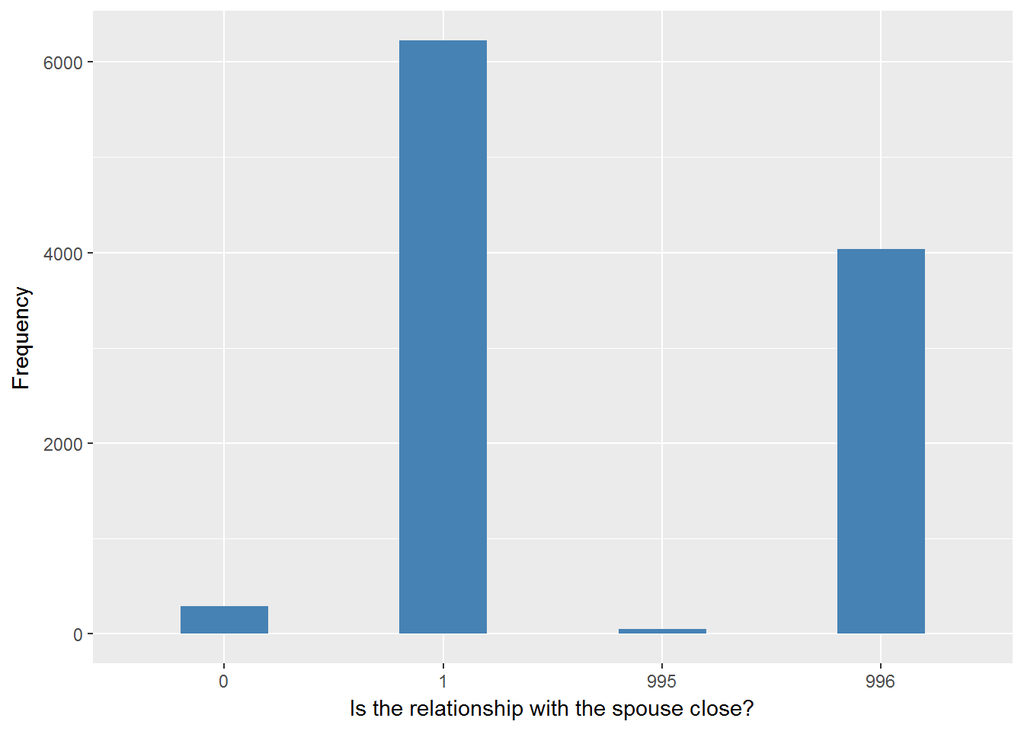

#### 2.1.6.4 Validation

|  | 3:4->0 | 1:2->1 | -9->995 | -1&-2->996 |
| --- | --- | --- | --- | --- |
| BeforeH1 | 293 | 6226 | 46 | 4036 |
| AfterH | 293 | 6226 | 46 | 4036 |

### 2.1.7 Wave 7

#### 2.1.7.1 Study-specific variable description

The study-specific variable elected to be harmonised is:

- Name: `scptrh`
- Label: `How close the respondents relationship to their spouse/partner is`
- Categories:
  - `1 = Very close`
  - `2 = Quite close`
  - `3 = Not very close`
  - `4 = Not at all close`
- Missings:
  - `-9 = Not answered (9)`
  - `-8 = Don't know (8)`
  - `-2 = Schedule Not Applicable`
  - `-1 = Item not applicable`

```
## $values_table
##               -9     -2      -1       1       2   3     4
## Frequency  44.00 1469.0 2221.00 4545.00 1166.00 193 28.00
## Percentage  0.46   15.2   22.98   47.02   12.06   2  0.29
##
## $n_table
##      Sample size Missing values
## [1,]        9666              0
```

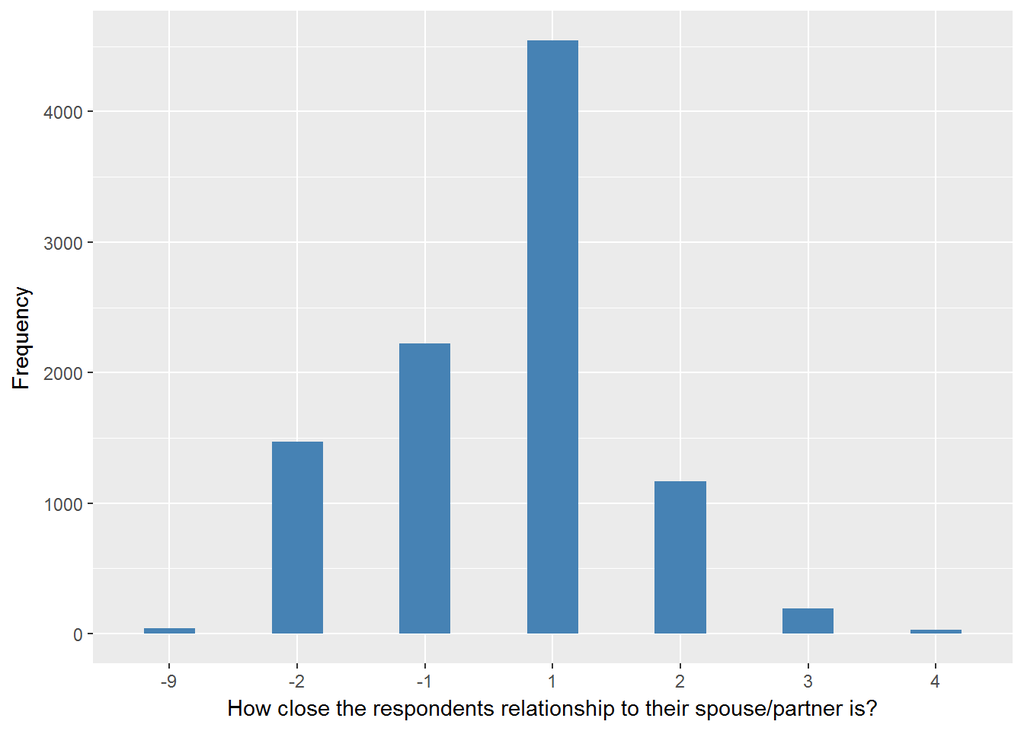

#### 2.1.7.2 Harmonisation algorithm

To compute the harmonize variable from the study-specific variable it has to be recoded as follows:

- `3 or 4 into 0`
- `1 or 2 into 1`
- `-9 into 995`
- `-8 into 998`
- `-2 into 996`
- `-1 into 996`
- `NA into 999`

**R script:**

```r
ELSA_ds_w7 <- tibble(id = ELSA_w7_close_spouse$id)
ELSA_ds_w7$close_spouse <- car::recode(as.vector(ELSA_w7_close_spouse$scptrh),
    "1:2='1'; 3:4='0'; -1='996'; -2='996'; -8='998'; -9='995'; NA='999'")
ELSA_ds_w7$close_spouse <- labelled(ELSA_ds_w7$close_spouse, labels = c(No = 0,
    Yes = 1, Missing = 999, `Do not know` = 998, Refuse = 997, `Not applicable` = 996,
    `Don't answer` = 995, `Not attempt/not done/not yet recorded` = 994, `Disable to measure` = 993,
    Impute = 992, `CAPI/interviewer error` = 991))
```

#### 2.1.7.3 Statistics of the new harmonised variable

```
## $values_table
##                 0       1
## Frequency  221.00 5711.00
## Percentage   2.29   59.08
##
## $missing_values_table
##            991 992 993 994   995     996 997 998 999 NA
## Frequency    0   0   0   0 44.00 3690.00   0   0   0  0
## Percentage   0   0   0   0  0.46   38.18   0   0   0  0
##
## $n_table
##      Sample size Missing values
## [1,]        9666           3734
```

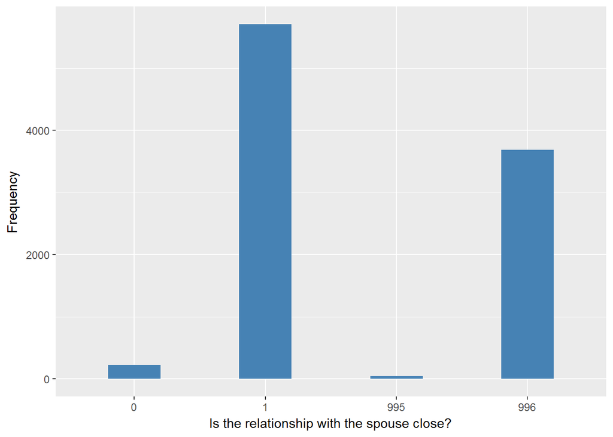

#### 2.1.7.4 Validation

|  | 3:4->0 | 1:2->1 | -9->995 | -1&-2->996 |
| --- | --- | --- | --- | --- |
| BeforeH1 | 221 | 5711 | 44 | 3690 |
| AfterH | 221 | 5711 | 44 | 3690 |

## 2.2 Summary of descriptive statistics of the harmonised variable accross populations and waves

Two tables are generated:

1. Percentages of categories in each harmonised variable.
2. Frequencies and percentages of individuals with different trajectories. To avoid too large table, Only trajectories with percentages larger than 0.3 are shown.

```r
t.hds <- frq(l.hds[[1]][2])[[1]][, c(1, 2)]
for (i in seq_along(l.hds)) {
    t.hds[2 + i] <- frq(l.hds[[i]][2])[[1]][, 4]
}
t.hds[13, ] <- c("n", "sample size", sapply(l.hds, function(wave) length(wave[[1]])))
names(t.hds) <- c("val", "label", names(l.hds))
kable(t.hds)
```

| val | label | w1 | w2 | w3 | w4 | w5 | w6 | w7 |
| --- | --- | --- | --- | --- | --- | --- | --- | --- |
| 0 | No | 2.35 | 2.1 | 2.33 | 2.33 | 2.44 | 2.76 | 2.29 |
| 1 | Yes | 62.56 | 60.59 | 58.14 | 59.04 | 60.08 | 58.73 | 59.08 |
| 991 | CAPI interviewer error | 0 | 0 | 0 | 0 | 0 | 0 | 0 |
| 992 | Impute | 0 | 0 | 0 | 0 | 0 | 0 | 0 |
| 993 | Disable to measure | 0 | 0 | 0 | 0 | 0 | 0 | 0 |
| 994 | Not attempt not done | 0 | 0 | 0 | 0 | 0 | 0 | 0 |
| 995 | Does not answer | 0.66 | 0.54 | 0.75 | 0.44 | 0.53 | 0.43 | 0.46 |
| 996 | Not applicable | 34.43 | 36.77 | 38.78 | 38.19 | 36.95 | 38.07 | 38.18 |
| 997 | Refuse | 0 | 0 | 0 | 0 | 0 | 0 | 0 |
| 998 | Do not know | 0 | 0 | 0 | 0 | 0 | 0 | 0 |
| 999 | Missing | 0 | 0 | 0 | 0 | 0 | 0 | 0 |
| NA | NA | 0 | 0 | 0 | 0 | 0 | 0 | 0 |
| n | sample size | 12099 | 9432 | 9771 | 11050 | 10274 | 10601 | 9666 |

```r
dbb <- get(paste0("ELSA_m_ds_", names(l.hds)[1]))[, c("id", "close_spouse")]
for (ind in 2:length(l.hds)) {
    dbb <- merge(dbb, get(paste0("ELSA_m_ds_", names(l.hds)[ind]))[, c("id",
        "close_spouse")], by = "id", suffixes = c("", paste0(".", names(l.hds)[ind])),
        all = T)
}
names(dbb) <- c("id", names(l.hds))

v.dbb <- dbb[, 2]
for (ind in 2:length(l.hds)) {
    v.dbb <- paste(v.dbb, dbb[, ind + 1], sep = "")
}
f.dbb <- frq(v.dbb)[[1]][, c(1, 2, 4)]
kable(f.dbb[f.dbb[, 3] >= 0.3, ])
```

|  | val | frq | raw.prc |
| --- | --- | --- | --- |
| 105 | 0NANANANANANA | 87 | 0.47 |
| 195 | 1111111 | 1869 | 10.11 |
| 196 | 111111NA | 349 | 1.89 |
| 198 | 11111NA1 | 70 | 0.38 |
| 199 | 11111NANA | 266 | 1.44 |
| 202 | 1111NA11 | 61 | 0.33 |
| 205 | 1111NANANA | 324 | 1.75 |
| 210 | 111NA111 | 126 | 0.68 |
| 218 | 111NANANANA | 557 | 3.01 |
| 229 | 11NA1111 | 118 | 0.64 |
| 251 | 11NANANANANA | 915 | 4.95 |
| 265 | 1NA11111 | 99 | 0.54 |
| 281 | 1NA1NANANANA | 111 | 0.60 |
| 308 | 1NANANANANANA | 1619 | 8.76 |
| 328 | NA111111 | 79 | 0.43 |
| 357 | NA1NANANANANA | 110 | 0.59 |
| 398 | NANA11111 | 420 | 2.27 |
| 399 | NANA1111NA | 92 | 0.50 |
| 401 | NANA111NANA | 55 | 0.30 |
| 406 | NANA11NANANA | 74 | 0.40 |
| 418 | NANA1NANANANA | 251 | 1.36 |
| 451 | NANANA1111 | 942 | 5.09 |
| 452 | NANANA111NA | 206 | 1.11 |
| 454 | NANANA11NA1 | 56 | 0.30 |
| 455 | NANANA11NANA | 170 | 0.92 |
| 458 | NANANA1NA11 | 67 | 0.36 |
| 462 | NANANA1NANANA | 318 | 1.72 |
| 474 | NANANANA111 | 121 | 0.65 |
| 475 | NANANANA11NA | 71 | 0.38 |
| 478 | NANANANA1NANA | 75 | 0.41 |
| 483 | NANANANANA11 | 563 | 3.05 |
| 484 | NANANANANA1NA | 207 | 1.12 |
| 486 | NANANANANANA1 | 430 | 2.33 |
| 487 | NANANANANANANA | 5540 | 29.96 |

# 3 Quality estimation